# Clustering Example

Data from Samsung Galaxy accelerometer

```r
load("./Data/samsungData.rda")
names(samsungData)[1:12]
```

```
##  [1] "tBodyAcc-mean()-X" "tBodyAcc-mean()-Y" "tBodyAcc-mean()-Z"
##  [4] "tBodyAcc-std()-X"  "tBodyAcc-std()-Y"  "tBodyAcc-std()-Z"
##  [7] "tBodyAcc-mad()-X"  "tBodyAcc-mad()-Y"  "tBodyAcc-mad()-Z"
## [10] "tBodyAcc-max()-X"  "tBodyAcc-max()-Y"  "tBodyAcc-max()-Z"
```

```r
table(samsungData$activity)
```

```
##
##   laying  sitting standing     walk walkdown   walkup
##     1407     1286     1374     1226      986     1073
```

We're going to try to predict what sort of activity the subject was doing based on training data.

#### Plotting average acceleration for first subject

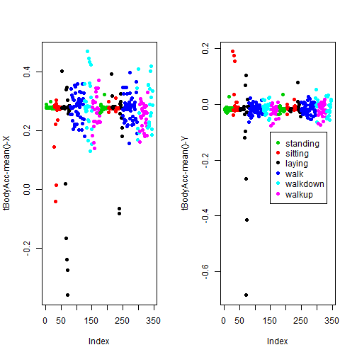

```r
par(mfrow = c(1, 2))
numericActivity <- as.numeric(as.factor(samsungData$activity))[samsungData$subject ==
    1]
# first subject, mean acceleration
plot(samsungData[samsungData$subject == 1, 1], pch = 19, col = numericActivity,
    ylab = names(samsungData)[1])
plot(samsungData[samsungData$subject == 1, 2], pch = 19, col = numericActivity,
    ylab = names(samsungData)[2])
legend(150, -0.1, legend = unique(samsungData$activity), col = unique(numericActivity),
    pch = 19)
```

#### Clustering based just on average acceleration

- Calculate distance between acceleration measurements, between all the activities performed by subject 1
- perform hierarchical clustering

```r
source("http://dl.dropbox.com/u/7710864/courseraPublic/myplclust.R")
distanceMatrix <- dist(samsungData[samsungData$subject == 1, 1:3])
hclustering <- hclust(distanceMatrix)
myplclustust(hclustering, lab.col = numericActivity)
```

[output not shown]

```
## Error: could not find function "myplclustust"
```

Max acceleration in each of the axis directions

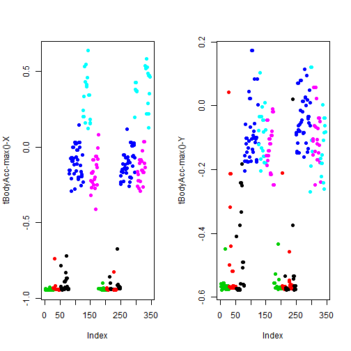

```r
par(mfrow = c(1, 2))
plot(samsungData[samsungData$subject == 1, 10], pch = 19, col = numericActivity,
    ylab = names(samsungData)[10])
plot(samsungData[samsungData$subject == 1, 11], pch = 19, col = numericActivity,
    ylab = names(samsungData)[11])
```

Now the data is distinguished better. Walking has higher acceleration than lying.

#### Clustering based on maximum acceleration

See how well the clusters are distinguished.

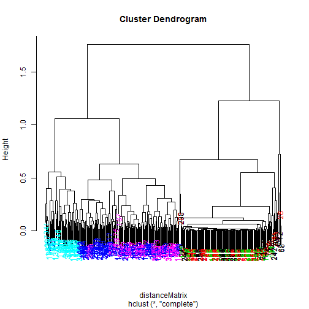

```r
distanceMatrix <- dist(samsungData[samsungData$subject == 1, 10:12])
hclustering <- hclust(distanceMatrix)
myplclust(hclustering, lab.col = numericActivity)
```

Walking and walking up is not clearly distinguished, but walking down gets its own cluster - far left baby blue.

The clustering is improved over using just the mean acceleration. To distinguish the other activities, we'll use SVD.

#### Singular value decomposition

- Rows: each subject
- columns: data collected with accelerometer - the data below leaves out subject (562) and activity (563) variables because we're not interested in those, just the Samsung data.

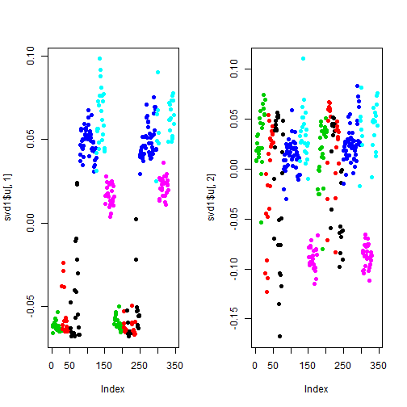

```r
svd1 = svd(scale(samsungData[samsungData$subject == 1, -c(562, 563)]))
par(mfrow = c(1, 2))
# first and second singular vectors
plot(svd1$u[, 1], col = numericActivity, pch = 19)
plot(svd1$u[, 2], col = numericActivity, pch = 19)
```

First singular vector distinguishes sitting lying standing from walking, walking up or down. Looks a lot like the max acceleration vector. The second singular vector is orthogonal (correlated) to the first one. In it walking up and down is distinguished. The left singular vector represents an average over the patterns in data set. We want to see if we can discover what are the variables that we're observing. To do this:

#### Find maximum contributor

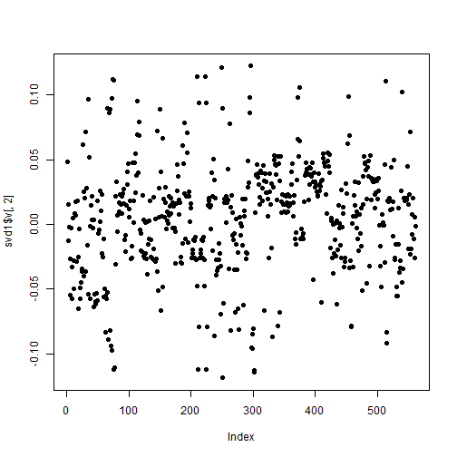

```r
plot(svd1$v[, 2], pch = 19)
```

We're looking at all the variables and weights that they contribute to the pattern that is the second singular vector. We may want to pick up the heaviest variables, ones that contribute the most variation and include that variable when we do our clustering.

#### New clustering with maximum contributor

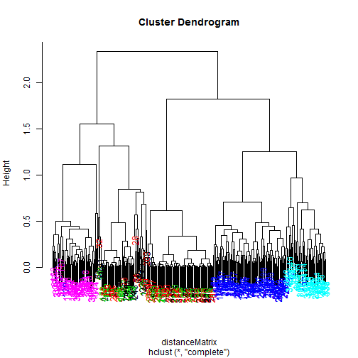

```r
# second singular vector, the one that distinguished walking up from
# walking down
maxContrib <- which.max(svd1$v[, 2])
# max acceleration variables and max contributor variable
distanceMatrix <- dist(samsungData[samsungData$subject == 1, c(10:12, maxContrib)])
hclustering <- hclust(distanceMatrix)
myplclust(hclustering, lab.col = numericActivity)
```

Now you can see more variables separated.

#### New clustering with maximum contributor

We can go back and see what variable it was that contributed the above.

```r
names(samsungData)[maxContrib]
```

```
## [1] "fBodyAcc-meanFreq()-Z"
```

Mean frequency for the Z variable will separate walking from walking upstairs.

#### K-means clustering (nstart=1, first try)

Same data is omited as before. We want 6 clusters, then we make a table of what cluster we want the data in vs what activity the subject was performing.

```r
kClust <- kmeans(samsungData[samsungData$subject == 1, -c(562, 563)], centers = 6)
table(kClust$cluster, samsungData$activity[samsungData$subject == 1])
```

```
##
##     laying sitting standing walk walkdown walkup
##   1     20      13        3    0        0      0
##   2      0       0        0    0       48      0
##   3      0       0        0   45        0      0
##   4     26      34       50    0        0      0
##   5      4       0        0    0        0     53
##   6      0       0        0   50        1      0
```

#### K-means clustering (nstart=1, second try)

```r
kClust <- kmeans(samsungData[samsungData$subject == 1, -c(562, 563)], centers = 6,
    nstart = 1)
table(kClust$cluster, samsungData$activity[samsungData$subject == 1])
```

```
##
##     laying sitting standing walk walkdown walkup
##   1      0       9       25    0        0      0
##   2      8       2        0    0        0      0
##   3     27       0        0    0        0      0
##   4      0      28       27    0        0      0
##   5      0       0        0   95       49     53
##   6     15       8        1    0        0      0
```

Clusters differ from the first time, to remedy that we can give the algorithm more starts.

#### K-means clustering (nstart=100, first try)

```r
kClust <- kmeans(samsungData[samsungData$subject == 1, -c(562, 563)], centers = 6,
    nstart = 100)
table(kClust$cluster, samsungData$activity[samsungData$subject == 1])
```

```
##
##     laying sitting standing walk walkdown walkup
##   1      3       0        0    0        0     53
##   2     29       0        0    0        0      0
##   3     18      10        2    0        0      0
##   4      0      37       51    0        0      0
##   5      0       0        0   95        0      0
##   6      0       0        0    0       49      0
```

Running it again gives a similar example, ordering may be unstable.

We can look at what each of the clusters means

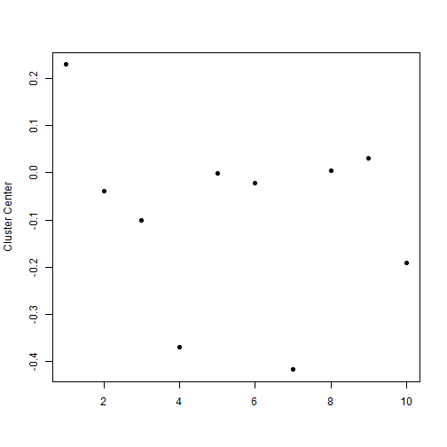

```r
plot(kClust$center[1, 1:10], pch = 19, ylab = "Cluster Center", xlab = "")
```

First 3 variables represent mean acceleration X, Y, Z, etc

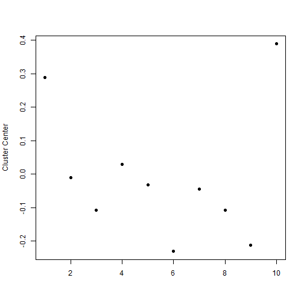

```r
plot(kClust$center[6, 1:10], pch = 19, ylab = "Cluster Center", xlab = "")
```

# Basic Least Squares

Regression

## Example: Average parent and child heights

Still better to use mid-heights than genetic indicators.

#### Load Galton Data

```r
library(UsingR)
```

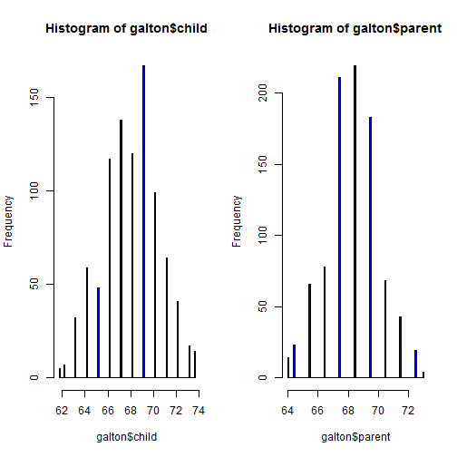

```r
data(galton)
par(mfrow = c(1, 2))
hist(galton$child, col = "blue", breaks = 100)
hist(galton$parent, col = "blue", breaks = 100)
```

#### Only know the child - average height

How do we brake up this distribution? We can use the mean.

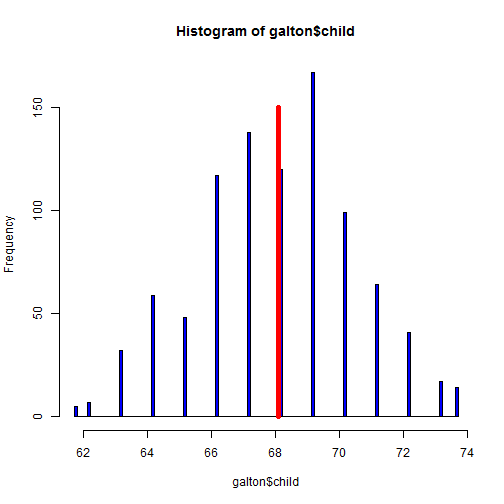

```r
hist(galton$child, col = "blue", breaks = 100)
meanChild <- mean(galton$child)
lines(rep(meanChild, 100), seq(0, 150, length = 100), col = "red", lwd = 5)
```

#### Why average?

If \( C_i \) is the height of child \( i \) then the average is the value of \( \mu \) that minimizes: \[ \sum\limits_{i=1}^928 (C_i-\mu\)^2 \]

#### What if we plot child versus average parent

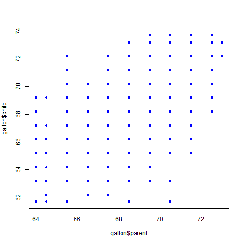

```r
plot(galton$parent, galton$child, pch = 19, col = "blue")
```

There seems to be a relationship. Data stacked because of lack of many significant digits. You can add jitter.

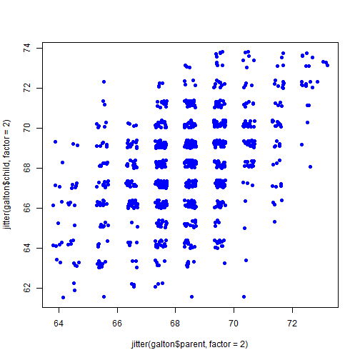

```r
set.seed(1234)
plot(jitter(galton$parent, factor = 2), jitter(galton$child, factor = 2), pch = 19,
    col = "blue")
```

#### Average parent=65 inches tall

Other way to look at different ways to predict child height.

Average child height for parents that have some average height: 65 inches

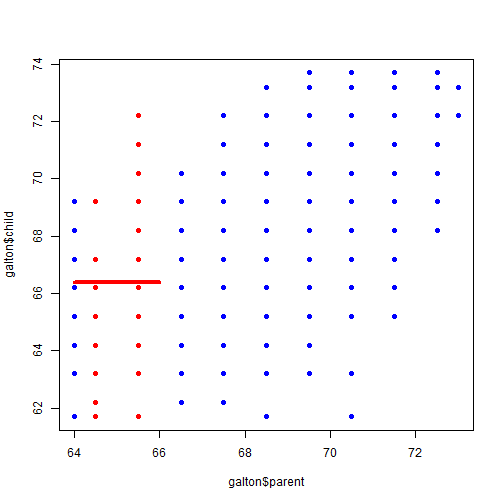

```r
plot(galton$parent, galton$child, pch = 19, col = "blue")
near65 <- galton[abs(galton$parent - 65) < 1, ]
points(near65$parent, near65$child, pch = 19, col = "red")
lines(seq(64, 66, length = 100), rep(mean(near65$child), 100), col = "red",
    lwd = 4)
```

#### Fitting a line

lm: linear model: quantitative outcome on left ~ variables to include in model

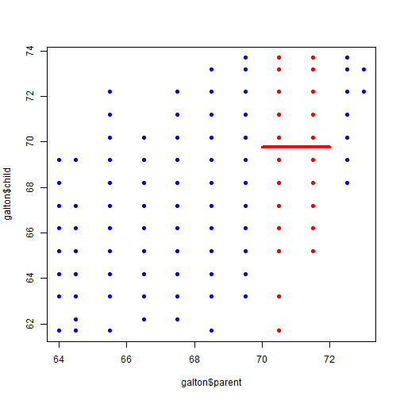

```r
plot(galton$parent, galton$child, pch = 19, col = "blue")
near71 <- galton[abs(galton$parent - 71) < 1, ]
points(near71$parent, near71$child, pch = 19, col = "red")
lines(seq(70, 72, length = 100), rep(mean(near71$child), 100), col = "red",
    lwd = 4)
```

#### The equation for a line

If \( C_i \) is the height of a child \( i \) and \( P_i \) is the height of the average parent, then we can imagine riting the equation for a line: \[ C_i=b_0+b_1P_i \] Adding an error term \[ C_i=b_0+b_1P_i+e_i \] $e_i is everything we didn't measure (how much they eat, where they live, do they stretch in the morning…)

#### How do we pick best?

If \( C_i \) is the height of child \( i \) and \( P_i \) is the height of the average parent, pick the line that makes the child values \( C_i \) and our guesses \[ \sum\limits_{i_1}^928 (C_i-\{b_0+b_1P_i\})^2 \] We have height and want to estimate based it on some variable (the line in {} in this case). We pick \( b_0 \) and \( b_1 \) that make the equation smallest. That's what `lm` does.

```r
par(mfrow = c(1, 2))
plot(galton$parent, galton$child, pch = 19, col = "blue")
lines(galton$parent, lm1$fitted, col = "red", lwd = 3)
```

```
## Error: object 'lm1' not found
```

```r
plot(galton$parent, lm1$residuals, col = "blue", pch = 19)
```

[output not shown]

```
## Error: object 'lm1' not found
```

[figure not shown]

```r
abline(c(0, 0), col = "red", lwd = 3)
```

# Inference Basics

What can we tell about the data?

## Fit a line to the Galton Data

Average parent height vs child height. `lm` always fits an intercept term, unless you tell it not to.

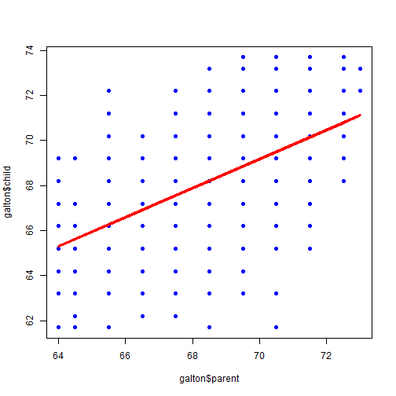

```r
library(UsingR)
data(galton)
plot(galton$parent, galton$child, pch = 19, col = "blue")
lm1 <- lm(galton$child ~ galton$parent)
lines(galton$parent, lm1$fitted, col = "red", lwd = 3)
```

If you increase parent's height by one unit (1 inch in this case), you'll get a corresponding change in child's height by 0.646 unit.

```r
lm1
```

```
##
## Call:
## lm(formula = galton$child ~ galton$parent)
##
## Coefficients:
##   (Intercept)  galton$parent
##        23.942          0.646
```

### Create a “population” of 1 million families

Based on fit from original data set. We'll generate the parent's heights with mean being the mean we got from the Galton data set and sd from Galton. We also make up child heights from the model we fit on the Galton data. Intercept term from the galton model `lm1$coeff[1]` + slope, `lm1$coeff[2]` * parent value + some noise with `rnorm` so not all points lie on the line.

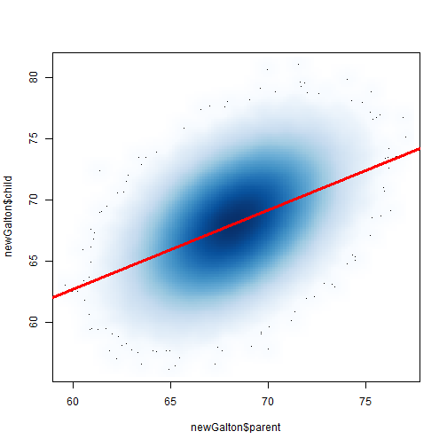

```r
newGalton <- data.frame(parent = rep(NA, 1e+06), child = rep(NA, 1e+06))
newGalton$parent <- rnorm(1e+06, mean = mean(galton$parent), sd = sd(galton$parent))
newGalton$child <- lm1$coeff[1] + lm1$coeff[2] * newGalton$parent + rnorm(1e+06,
    sd = sd(lm1$residuals))
smoothScatter(newGalton$parent, newGalton$child)
abline(lm1, col = "red", lwd = 3)
```

### Let's take a sample: 1

Hypothetically - We can take a sub-sample of those million families and generate a new line. We sample size 50 with no replacement, then we fit a linear model. Red line is the original data, black is the new liear model on the sub-sample.

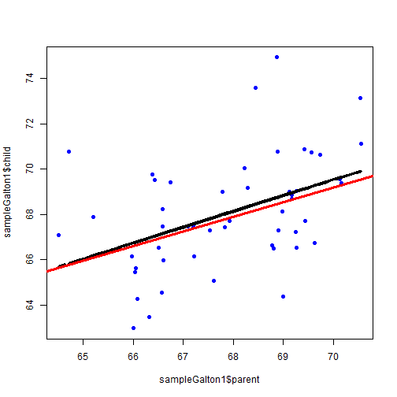

```r
set.seed(134325)
sampleGalton1 <- newGalton[sample(1:1e+06, size = 50, replace = F), ]
sampleLm1 <- lm(sampleGalton1$child ~ sampleGalton1$parent)
plot(sampleGalton1$parent, sampleGalton1$child, pch = 19, col = "blue")
lines(sampleGalton1$parent, sampleLm1$fitted, lwd = 3, lty = 2)
abline(lm1, col = "red", lwd = 3)
```

### Sample: 2

Using a different sub-sample.

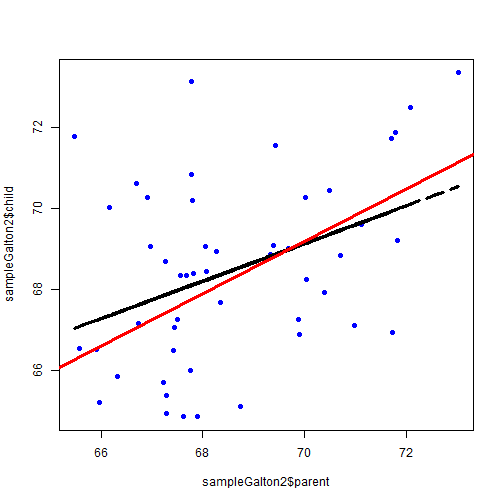

```r
sampleGalton2 <- newGalton[sample(1:1e+06, size = 50, replace = F), ]
sampleLm2 <- lm(sampleGalton2$child ~ sampleGalton2$parent)
plot(sampleGalton2$parent, sampleGalton2$child, pch = 19, col = "blue")
lines(sampleGalton2$parent, sampleLm2$fitted, lwd = 3, lty = 2)
abline(lm1, col = "red", lwd = 3)
```

### Sample: 3

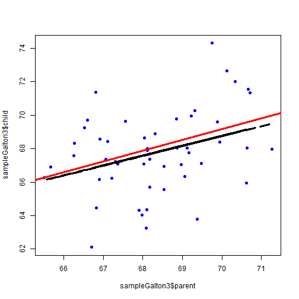

```r
sampleGalton3 <- newGalton[sample(1:1e+06, size = 50, replace = F), ]
sampleLm3 <- lm(sampleGalton3$child ~ sampleGalton3$parent)
plot(sampleGalton3$parent, sampleGalton3$child, pch = 19, col = "blue")
lines(sampleGalton3$parent, sampleLm3$fitted, lwd = 3, lty = 2)
abline(lm1, col = "red", lwd = 3)
```

### Many samples

We can do the above lots of times.

```r
sampleLm <- vector(100, mode = "list")
for (i in 1:100) {
    sampleGalton <- newGalton[sample(1:1e+06, size = 50, replace = F), ]
    sampleLm[[i]] <- lm(sampleGalton$child ~ sampleGalton$parent)
}
```

and plot.

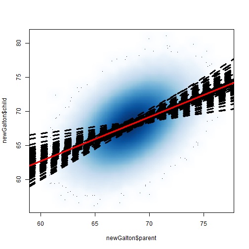

```r
smoothScatter(newGalton$parent, newGalton$child)
for (i in 1:100) {
    abline(sampleLm[[i]], lwd = 3, lty = 2)
}
abline(lm1, col = "red", lwd = 3)
```

Repeatedly applied a linear to the sample data sets.

### Histogram of estimates

If we were to tell something about the red line, but all we had was one of the black lines, what would we be able to say. We plot a histogram.

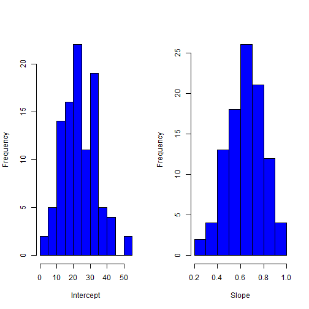

```r
par(mfrow = c(1, 2))
hist(sapply(sampleLm, function(x) {
    coef(x)[1]
}), col = "blue", xlab = "Intercept", main = "")
hist(sapply(sampleLm, function(x) {
    coef(x)[2]
}), col = "blue", xlab = "Slope", main = "")
```

However, we usually only have one sample.

### Distribution of coefficients

From central limit theorem, it turns out that in many cases \( \hat{b}_0 \), the estimate of intercept and \( \hat{b}_1 \), the estimate of slope, follow normal distributions with mean \( b_0 \) and \( b_1 \): \[ \hat{b}_0~(N(b_0, Var(\hat{b}_0)))\\ \hat{b}_1~(N(b_0, Var(\hat{b}_1)))\\\\ \] We may not know what the variances are exactly but we can estimate with: \[ \hat{b}_0\approx(N(b_0, \hat{Var(\hat{b}_0)}))\\ \hat{b}_1\approx(N(b_1, \hat{Var(\hat{b}_1)})) \]

\( \sqrt{\hat{Var}(\hat{b}_0)} \) is the “standard error” of the estimate \( \hat{b}_0 \) and is abbreviated \( S.E.(\hat{b}_0) \)

### Estimating the values in R

We take a subsample of size 50 and fit a linear model. We look at coefficients, second row is the slope.

```r
sampleGalton4 <- newGalton[sample(1:1e+06, size = 50, replace = F), ]
sampleLm4 <- lm(sampleGalton4$child ~ sampleGalton4$parent)
summary(sampleLm4)
```

```
##
## Call:
## lm(formula = sampleGalton4$child ~ sampleGalton4$parent)
##
## Residuals:
##    Min     1Q Median     3Q    Max
## -4.391 -1.805 -0.434  1.912  5.966
##
## Coefficients:
##                      Estimate Std. Error t value Pr(>|t|)
## (Intercept)             9.859     13.831    0.71  0.47941
## sampleGalton4$parent    0.851      0.202    4.22  0.00011 ***
## ---
## Signif. codes:  0 '***' 0.001 '**' 0.01 '*' 0.05 '.' 0.1 ' ' 1
##
## Residual standard error: 2.58 on 48 degrees of freedom
## Multiple R-squared: 0.27,    Adjusted R-squared: 0.255
## F-statistic: 17.8 on 1 and 48 DF,  p-value: 0.000109
```

The distribution of slopes if we ran the study 100 different times (`hist`) and the red line is the distribution that we estimate using the one slope and variance (S.E.) from the above sub-sample. Variance is about the same, Slope is slightly different.

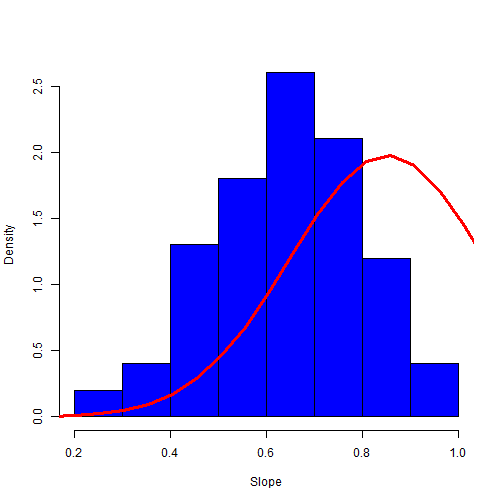

```r
hist(sapply(sampleLm, function(x) {
    coef(x)[2]
}), col = "blue", xlab = "Slope", main = "", freq = F)
lines(seq(0, 5, length = 100), dnorm(seq(0, 5, length = 100), mean = coef(sampleLm4)[2],
    sd = summary(sampleLm4)$coeff[2, 2]), lwd = 3, col = "red")
```

## Why do we standardize?

We want to be able to make comparisons and understanding of variables easier. Like converting Kelving to Celcius.

Suppose we want to identify we want to distribution is in the below model, without having all the different parameters.

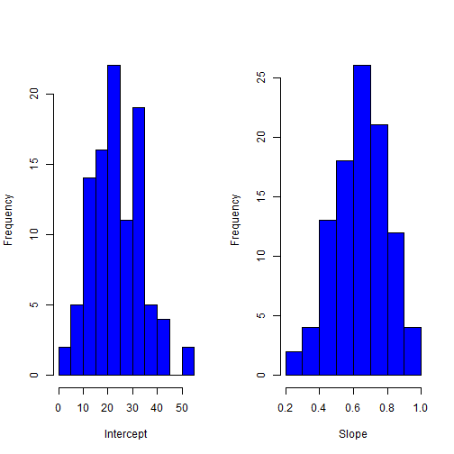

```r
par(mfrow = c(1, 2))
hist(sapply(sampleLm, function(x) {
    coef(x)[1]
}), col = "blue", xlab = "Intercept", main = "")
hist(sapply(sampleLm, function(x) {
    coef(x)[2]
}), col = "blue", xlab = "Slope", main = "")
```

#### Standardization Coefficients

\[ \hat{b}_0\approx(N(b_0, \hat{Var(\hat{b}_0)}))\\ \hat{b}_1\approx(N(b_1, \hat{Var(\hat{b}_1)}))\\\\ \] Turns out that if you do the below, where \( b_0 \) is the known mean value, it has what's called the T distribution, \( n-2 \) is the number of samples we had in our study - 2 degrees of freedom, which tell us how much variation we have left over after estimating the parameters. \[ \frac{\hat{b}_0-b_0}{S.E.(\hat{b}_0)}\textasciitilde t_n-2\\ \frac{\hat{b}_1-b_1}{S.E.(\hat{b}_1)}\textasciitilde t_n-2 \] Degrees of freedom \( \approx \) number of samples - number of things you estimated.

[output not shown]

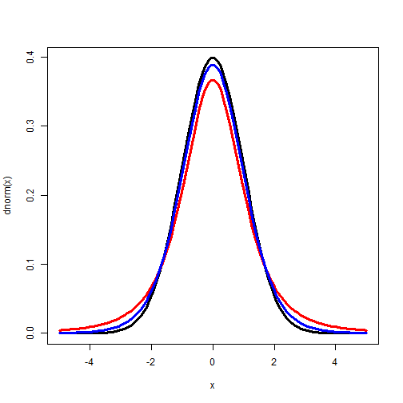

## Confidence intervals

We have an estimate \( \hat{b}_1 \) and we want to know something about how good our estimate is, like what the real \( b_1 \) is. One way is to create a “level \( \alpha \) confidence interval”.

The confidence interval will be a set of values for \( b_1 \) that we think are plausible. They're going to be divided. A confidence interval will include the parameter \( \alpha \) percent of the time in repeated studies. If we took the sample over and over (say 100 times) and recalculated the confidence interval in the same way, then we'd get 100 different intervals and of those, \( \alpha\% \) will cover the parameter that we actually care about.

The way we calculate them using T distribution and estimates of the S.E. that we calculate: \[ (\hat{b}_1-T_{\alpha/2}\times S.E.(\hat{b}_1), \hat{b}_1+T_{\alpha/2}\times S.E.(\hat{b}_1)) \] \( \hat{b}_1 \) and \( S.E.(\hat{b}_1) \) we estimate using `lm`. To get the confidence interval, we multiply using S.E. with the quantile of the T distribution, where the quantile is \( \alpha/2 \). We do + and - that to make a symmetric interval.

`cofint` performs this calculation - we tell it what confidence level we want the result to be in.

```r
summary(sampleLm4)$coeff
```

```
##                      Estimate Std. Error t value  Pr(>|t|)
## (Intercept)            9.8590    13.8309  0.7128 0.4794056
## sampleGalton4$parent   0.8515     0.2019  4.2172 0.0001089
```

```r
confint(sampleLm4, level = 0.95)
```

```
##                         2.5 % 97.5 %
## (Intercept)          -17.9499 37.668
## sampleGalton4$parent   0.4455  1.257
```

These have a statistical meaning in terms of the frequency the confidence interval covers the actual value.

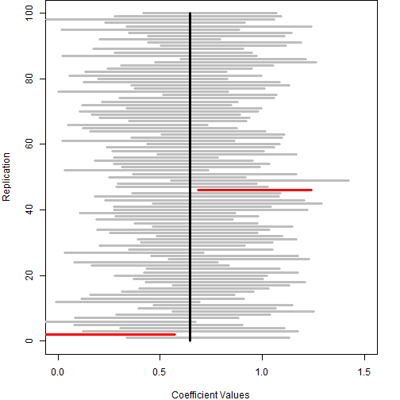

```r
par(mar = c(4, 4, 0, 2))
plot(1:10, type = "n", xlim = c(0, 1.5), ylim = c(0, 100), xlab = "Coefficient Values",
    ylab = "Replication")
for (i in 1:100) {
    ci <- confint(sampleLm[[i]])
    color = "red"
    if ((ci[2, 1] < lm1$coeff[2]) & (lm1$coeff[2] < ci[2, 2])) {
        color = "grey"
    }
    segments(ci[2, 1], i, ci[2, 2], i, col = color, lwd = 3)
}
lines(rep(lm1$coeff[2], 100), seq(0, 100, length = 100), lwd = 3)
```

## How you report the inference

We get the estimates for intercept and slope and confidence intervals for those values.

```r
sampleLm4$coeff
```

```
##          (Intercept) sampleGalton4$parent
##               9.8590               0.8515
```

```r
confint(sampleLm4, level = 0.95)
```

```
##                         2.5 % 97.5 %
## (Intercept)          -17.9499 37.668
## sampleGalton4$parent   0.4455  1.257
```

# P-values

- Most common measure of “statistical significance”
- Commonly reported in papers
- Used for decision making (e.g. FDA)
- [Controversial among statisticians](http://warnercnr.colostate.edu/%7Eanderson/thompson1.html), but [some find it useful](http://simplystatistics.org/2012/01/06/p-values-and-hypothesis-testing-get-a-bad-rap-but-we/)

## What is a P-value?

**Idea:** Suppose nothing is going on - how unusual is it to see the estimate we got?

**Approach:** 1. Define the hypothetical distribution of a data summary (statistic) when “nothing is going on” (null hypothesis) 2. Calculate the summary/statistic with the data we have (test statistic) 3. Compare what we calculated to our hypothetical distribution and see if the value is “extreme” (p-value)

## Galton data

Overlayed least squares line

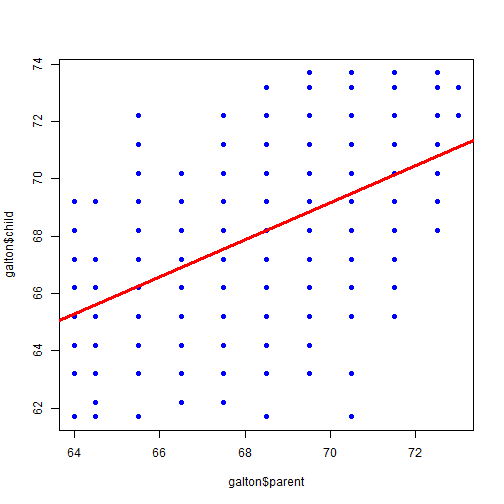

```r
library(UsingR)
data(galton)
plot(galton$parent, galton$child, pch = 19, col = "blue")
lm1 <- lm(galton$child ~ galton$parent)
abline(lm1, col = "red", lwd = 3)
```

### Null hypothesis/distribution

We can hypothesize there's no relationship between the variables.

\( \hat{b}_1 \) is the slope. If it was 0, the line would be horizontal, there'd be no relationship in the data.

The null hypothesis will be that \( \hat{b}_1=0 \)

\[ \frac{\hat{b}_1-b_1}{S.E.(\hat{b}_1)}\textasciitilde t_{n-2} \]

\( H_0 \): That there is no relationship between parent and child height (\( b_1=0 \)). Under the null hypothesis the distribution is:

\[ \frac{\hat{b}_1}{S.E.(\hat{b}_1)}\textasciitilde t_{n-2} \]

### Null distribution

2 degrees of freedom to estimate parameters.

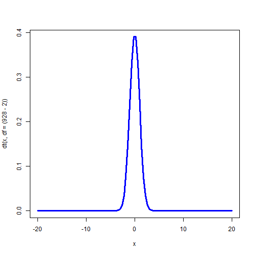

```r
x <- seq(-20, 20, length = 100)
plot(x, dt(x, df = (928 - 2)), col = "blue", lwd = 3, type = "l")
```

### Null distribution + observed statistic

The t statistic

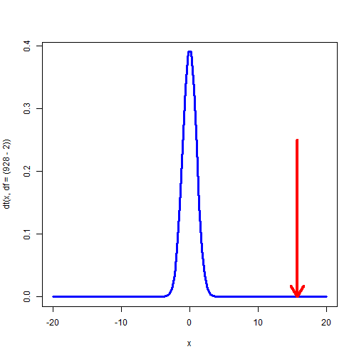

```r
x <- seq(-20, 20, length = 100)
plot(x, dt(x, df = (928 - 2)), col = "blue", lwd = 3, type = "l")
arrows(summary(lm1)$coeff[2, 3], 0.25, summary(lm1)$coeff[2, 3], 0, col = "red",
    lwd = 4)
```

If nothing was happening the t statistic would be drawn from closer to the mean of the distribution. So the result is unlikely.

### Cummulating p-values

```r
summary(lm1)
```

```
##
## Call:
## lm(formula = galton$child ~ galton$parent)
##
## Residuals:
##    Min     1Q Median     3Q    Max
## -7.805 -1.366  0.049  1.634  5.926
##
## Coefficients:
##               Estimate Std. Error t value Pr(>|t|)
## (Intercept)    23.9415     2.8109    8.52   <2e-16 ***
## galton$parent   0.6463     0.0411   15.71   <2e-16 ***
## ---
## Signif. codes:  0 '***' 0.001 '**' 0.01 '*' 0.05 '.' 0.1 ' ' 1
##
## Residual standard error: 2.24 on 926 degrees of freedom
## Multiple R-squared: 0.21,    Adjusted R-squared: 0.21
## F-statistic:  247 on 1 and 926 DF,  p-value: <2e-16
```

t value is estimate/standard error. p-value is small (Pr(>|t|))

### A quick simulated example

```r
set.seed(9898324)
yValues <- rnorm(10)
xValues <- rnorm(10)
lm2 <- lm(yValues ~ xValues)
summary(lm2)
```

```
##
## Call:
## lm(formula = yValues ~ xValues)
##
## Residuals:
##    Min     1Q Median     3Q    Max
## -1.546 -0.570  0.136  0.771  1.052
##
## Coefficients:
##             Estimate Std. Error t value Pr(>|t|)
## (Intercept)    0.310      0.351    0.88     0.40
## xValues        0.289      0.389    0.74     0.48
##
## Residual standard error: 0.989 on 8 degrees of freedom
## Multiple R-squared: 0.0644,  Adjusted R-squared: -0.0525
## F-statistic: 0.551 on 1 and 8 DF,  p-value: 0.479
```

The p value says that we're not at all surprised to see estimate of 0.289 with the given std error if nothing is happening.

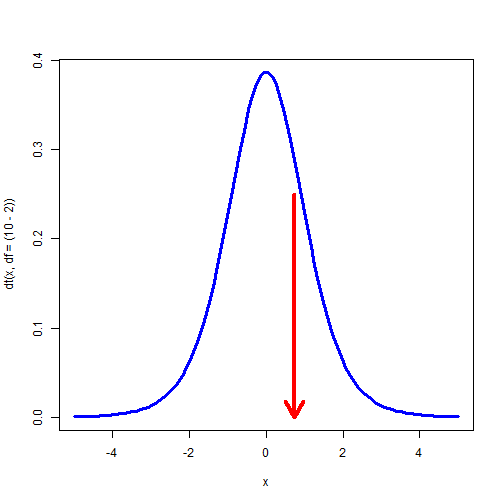

```r
x <- seq(-5, 5, length = 100)
plot(x, dt(x, df = (10 - 2)), col = "blue", lwd = 3, type = "l")
arrows(summary(lm2)$coeff[2, 3], 0.25, summary(lm2)$coeff[2, 3], 0, col = "red",
    lwd = 4)
```

Showing 8 degrees of freedom, because we have sample of 10 with 2 degrees of freedom to estimate the parameters. The t stat falls hear center, so we see it's not unlikely.

The way we calculate the unlikely or extreme is we take the statistic and look at how much density is to the right.

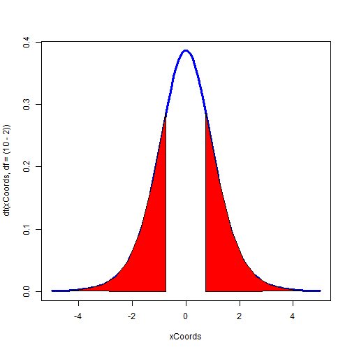

```r
xCoords <- seq(-5, 5, length = 100)
plot(xCoords, dt(xCoords, df = (10 - 2)), col = "blue", lwd = 3, type = "l")
xSequence <- c(seq(summary(lm2)$coeff[2, 3], 5, length = 10), summary(lm2)$coeff[2,
    3])
ySequence <- c(dt(seq(summary(lm2)$coeff[2, 3], 5, length = 10), df = 8), 0)
polygon(xSequence, ySequence, col = "red")
polygon(-xSequence, ySequence, col = "red")
```

Extreme could be positive or negative, so we take to the right and we reflect the statistic around 0 and take to the left. We say “extreme in magnitude”. The area ends up being equal to p-value. If the statistic falls in the center of the area, we're going to get most of the area under the curve. Since this is a distribution, we know the area = 1, so if it lands at 0, we get a p-value of 1 and if on outskirts, we get a tiny value.

### Simulate a ton of data sets with no signal

P values have some properties and they're important to know when performing these sorts of analises. 1. suppose we perform lots of studies and in each one there's no relationship between the x values and y values.

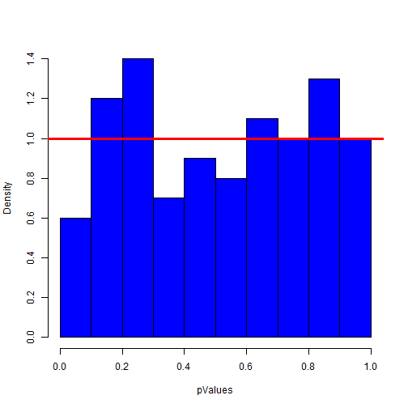

```r
set.seed(8323)
pValues <- rep(NA, 100)
for (i in 1:100) {
    xValues <- rnorm(20)
    yValues <- rnorm(20)
    pValues[i] <- summary(lm(yValues ~ xValues))$coeff[2, 4]
}
hist(pValues, col = "blue", main = "", freq = F)
abline(h = 1, col = "red", lwd = 3)
```

We see that the p-values are equally likely to take any value from 0 to 1 (uniform distribution). The more studies, the more apparent that is.